# 2 Simple Linear Regression

## Fitting models to data

in the previous section, you were given a linear model - we knew the values of $\beta_0$, $\beta_1$ and even $\sigma$. However, in most contexts we don’t know the true relationship between $X$ and $Y$ in advance. Instead, we are given *data* and try to *infer* the values of $\beta$ and $\sigma$ by analysing the data.

**Plot**

**Data**

your task for the remainder of the chapter (and in regression generally) is to try an make a (educated) guess about what model produced this data.

- Continue

## 2.1 Estimating parameters

We call the process of trying to guess the parameters in the data generating model (i.e. $\beta$ and $\sigma$), *estimation*, and our guesses are *estimates*. To avoid confusion, we distinguish our estimates from the ‘true’ parameter values by giving them $\hat{\text{hats}}$. So, we have

$$\hat{\beta_0}: \text{Estimated intercept}$$
$$\hat{\beta_1}: \text{Estimated slope}$$
$$\hat{\sigma}: \text{Estimated standard deviation}.$$
We also define $\hat{Y}$ as the predicted value of $Y$ given our estimated model:
$$\hat{Y}=\hat{\beta_0}+\hat{\beta_1}X$$
Looking at some data, we try to find the values of our parameters that best ‘fit’ its distribution. Adjust the sliders below to find a line that you think fits the data:

[interactive chart not shown]

**Exercise 1**

What is your best estimate for the values of $\beta_0$ and $\beta_1$ that best fit the given data?

Ok great, so we have an estimate for our line-of-best-fit:

[interactive chart not shown]

but what do we mean by ‘best’ fit here? How do we evaluate this estimate and maybe compare it to other estimates?

- Continue

### Residuals

Residuals are the difference between observed values of $Y$, and the value predicted by our estimated linear predictor $\hat{Y}$. We denote residuals with the letter $e$:
$$e=Y-\hat{Y} = Y - \hat{\beta_0}+\hat{\beta_1}X.$$

Residuals, $e$, are similar to the errors, $\varepsilon$, that we encountered in chapter 1 - but they are distinct. In many situations, we do not know the ‘acutual’ values of $\beta_0$ an $\beta_1$ - so we cannot calculate the errors, $\varepsilon= Y- E[Y]= Y-\beta_0 + \beta_1 X$. However, we do have our estimates, $\hat{\beta_0}$ and $\hat{\beta_1}$, so we can calculate residuals.

Indeed - calculating residuals gives us a way to assess how well our estimated model fits the data. We can think of the residuals as being the ‘mismatch’ between our estimated linear predictor and each data point. By *minimizing* the size of residuals (minimisiong the mismatch of our model to the data), we can get a better fit of our line to data.

- Continue

### Estimating $\beta$ by minimising residuals

#### how low can the (squared) residuals go?

Below, the plot now also displays residuals for each data point. Underneath the model equation is the *Sum of Squared Residuals* (SSR), which gives a measure of the absolute difference between our linear predictor and the observed outcomes.

$$SSR=\sum_{i=1}^{n} e_i^2$$

where $e_i = Y_i - \hat{Y}_i$. This gives us a numerical measure of how well the line fits the data - see how low you can get the SSR by adjusting slope and intercept.

[interactive chart not shown]

**Exercise 2**

Based on this visualisation, what do you think is the minimum possible $SSR$ achievable?

If you want you can update your $\hat{\beta}$ estimates too (otherwise just proceed):

**Technical-point 1:** Why squares?**

The least squares estimator chooses $\hat \beta_0$ and $\hat \beta_1$ so that the sum of squared residuals $\sum_{i=1}^{n} e_i^2$ is as small as possible. But why take squares? As mentioned, squaring numbers returns a positive result. Therefore the square gives some idea of the ‘absolute’ value of the residuals (and doesn’t allow negative residuals to cancel out positve ones). But why not just take the absolute value? Because the square function penalises large deviations heavily, least squares prefers lines that keep every point reasonably close to the fitted value rather than letting a few points drift far away.

### Fitting a model using least squares

We call the estimates $\hat{\beta_0}$ and $\hat{\beta_1}$ which minimise the sum of squares the *least squares estimates*. Some nice mathematics tells us that the least squares esimates for a simple linear model are *unique* - that is, there is one set of values for $\hat{\beta_0}$ and $\hat{\beta_1}$ which satisfy this property. Moreover, we don’t have to manually adjust our parameters to keep lowering SSR - there is a convenient closed form expression which allows us to compute $\hat{\beta_0}$ and $\hat{\beta_1}$ very efficiently. As a statistical programming language, this is something R does very easily..

#### The `lm()` function

- How do these estimates compare with yours?

**Plot**

**Code**

- Continue

### Estimating $\sigma$

We can extract the individual residual values from the fitted `lm` object by indexing (e.g. `my_lm$residuals`) or with the `residuals()` function.

**Exercise 3:** Extracting residuals from an lm object**

Extract the residuals by indexing our least squares fitted model `lm_1` and assign them to the variable `e`

### Residual Standard Error

**Exercise 4:** Calculate the Residual Standard Error**

using your `e` object defined in the previous exercise, calculate the residual standard error of the least squares model (hint - there are 20 observations in the linearData dataset)

- Continue

## 2.2 Checking assumptions

### Independence of observations

**Example 1**

Researchers are interested in the relationship between IQ measurement and alcohol consumption. To this end they design a study wherein they visit a nearby pub over several days and measure individual’s IQ and the amount of alcohol they’ve consumed.

Here is a plot of the data they collected:

**Plot**

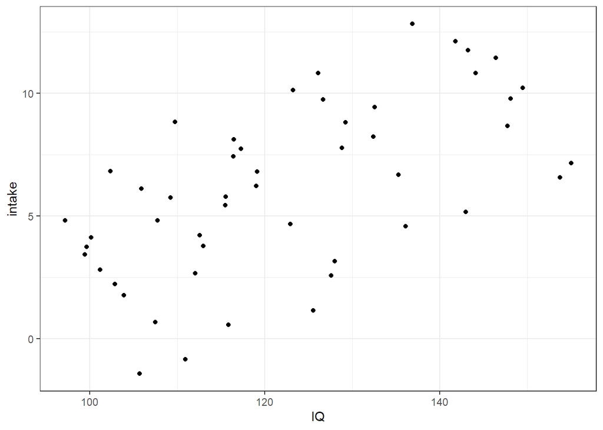

**Code**

```r
nonindependence_df |>
  ggplot() +
  aes(x = IQ, y = intake) +
  geom_point()
```

Fitting a simple linear model of IQ~Alcohol intake, would suggest that higher alcohol intake is associated with higher IQ scores. indeed, we can visualise a simple linear fit with the `geom_smooth(method="lm")` function

**Plot**

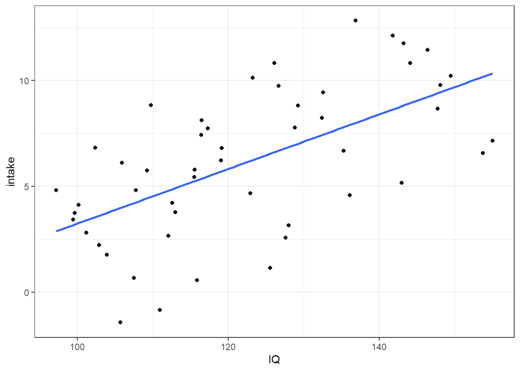

**Code**

```r
nonindependence_df |>
  ggplot() +
  aes(x = IQ, y = intake) +
  geom_point()+
  geom_smooth(method="lm", se=FALSE)
```

which shows this positive trend. In some sense this is what the data shows, however it is not the whole story. Consider the following plot, with each observation coloured by participant:

**Plot**

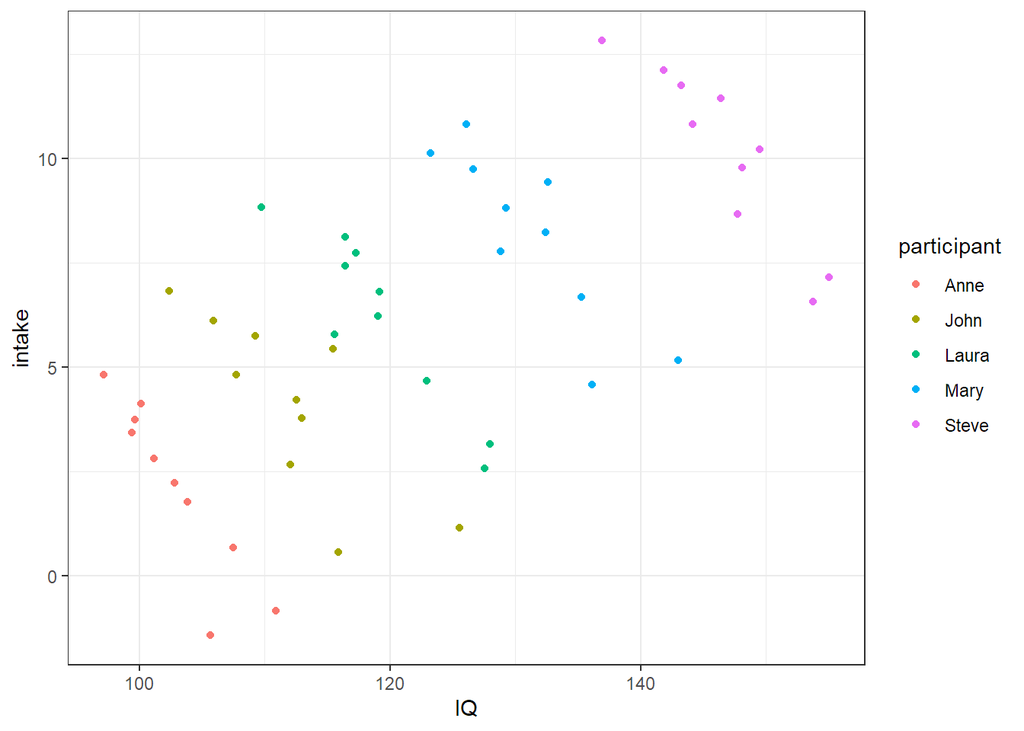

**Code**

```r
nonindependence_df |>
  ggplot() +
  aes(x = IQ, y = intake, colour = participant) +
  geom_point()
```

We can see that multiple observations (points) originate from the same participant - and therefore are likely to associated with one another. Moreover, if we focus on linear trends within each individual, our model(s) tell a different story:

**Plot**

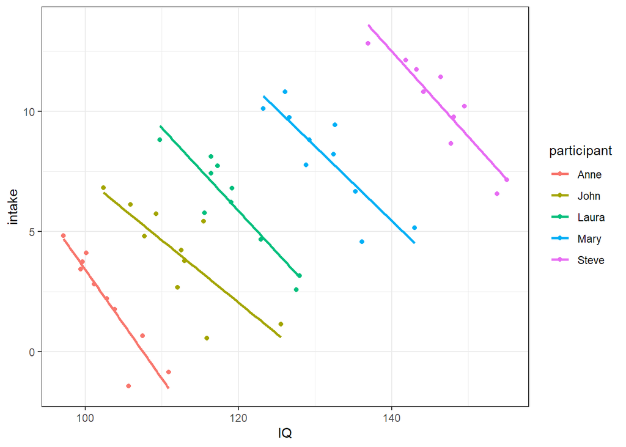

**Code**

```r
nonindependence_df |>
  ggplot() +
  aes(x = IQ, y = intake, colour = participant) +
  geom_point()+
  geom_smooth(method="lm", se=FALSE)
```

### Constant Variance

- **What it means:** Also called homoscedasticity, the variability of residuals should stay roughly constant across fitted values.
- **Diagnostics:** Residual-versus-fitted plots should show an even vertical spread.
- **Warning signs:** Funnel or fan shapes (narrow for small $\hat y$ but wide for large $\hat y$) reveal heteroscedasticity.
- **Possible remedies:** Transform the response, use weighted least squares, or model the variance explicitly.

### Normality of error

- **What it means:** Least squares inference (confidence intervals, hypothesis tests) assumes residuals are approximately normal.
- **Diagnostics:** Use a normal Q-Q plot to compare residual quantiles with the theoretical normal line.
- **Warning signs:** Systematic bends or heavy tail departures from the diagonal indicate skewness or heavy tails.
- **Possible remedies:** Transform the response, refit with robust methods, or collect more data to stabilise the distribution.

### Examples of assumption violations

- **Simulated example:** In this case the assumptions holdâ€”as expected because the data were sampled from an actual linear model.
- **Real-world contrasts:** Add case studies where independence fails (e.g., repeated measures), the relationship is curved, the variance changes, or the residuals are non-normal.
- **Teaching tip:** For each violation, include visuals showing the problematic residual pattern and a suggested fix.

**Example 2**

**Linearity**

**Example 3**

**Constant variance**

**Example 4**

**Normality**

## 2.3 Inference for Simple Linear Regression

- Repeating this process produces the sampling distribution of our parameters.
- in the real world we wont have the luxury of generating new samples by running R commands, so we have to make do with the data we have. Thankfully, if our assumptions of the underlying model are true then we can expect the same process of convergence to a stable sampling distribution to hold true and our parameter estimates for beta to have a t-distribution.

### Inference about $\beta$

- **Objective:** Derive sampling distributions for $\hat{\beta}_0$ and $\hat{\beta}_1$ under the model assumptions.
- **Key results:** Emphasise unbiasedness, variance formulas, and the joint normality of the estimators.
- **Confidence intervals:** Outline the structure $\hat{\beta} \pm t_{n-2,\alpha/2} \cdot \operatorname{SE}(\hat{\beta})$.
- **Hypothesis tests:** Summarise how to test linear contrasts of the coefficients using t-statistics.

## 2.4 Interpreting `summary()` output

- **Purpose:** `summary()` wraps the model fit, assumptions, and inference into a single report.
- **Coefficients table:** Highlight estimates, standard errors, t-values, and p-values for $\beta_0$ and $\beta_1$.
- **Residual standard error:** Connect this to $\hat \sigma$ and the degrees of freedom shown in the output.
- **Model fit metrics:** Explain multiple $R^2$ and adjusted $R^2$ as measures of explained variation.
- **Overall test:** Describe how the F-statistic in simple regression aligns with the $\beta_1$ t-test.
- **Workflow tip:** Encourage students to read the table line by line, linking each quantity back to the modelling steps above.

Interpreting each component in context helps translate the statistical output into practical insight about the data.

## 2.5 Using the model for prediction

- **Prerequisite:** Only use the model for prediction after diagnostics suggest the assumptions hold.
- **Point prediction:** Use `predict()` to obtain fitted values for new $x$.
- **Interval estimates:** Emphasise the difference between confidence intervals for the mean response and prediction intervals for individual outcomes.
- **Communicating uncertainty:** Always report the uncertainty associated with predictions.
- **Scope of application:** Warn about extrapolating beyond the observed range of $x$ and discuss potential pitfalls.

## 2.6 possible exercises

- calculate residuals manually from beta coefficients